[figure not shown]

# Python Programming (ACFI827)

# Assignment 2: Stock Market Data Analysis

### $\color{red}{\text{Deadline: 13 Jan 2023, 12:00 (Noon)}}$

## `1. Instructions for Conducting Assignment`

### 1.1 How to approach this assignment?

First, try to understand the problem statement and data provided to solve this problem. Break the program into small tasks, then tackle them individually. This assignment is designed to enhance the level of understanding of the given problem. It has four tasks (`Task 1` to `Task 4`). These tasks are ordered logically to an increasing level of difficulty. You probably want to write down essential information and solve some calculations on paper to understand the requirements and check some calculations later by your code. You can check calculations such as the size of the merged dataset through simple examples. Manually checking the expected outcome by the code is not a good practice; however, the programmer must understand the desired input and output to the code. A manual calculation to test functions in a code is not a feasible approach for real-life problems because the solution could be very complex, manual checks could be too time-consuming and, in some cases, impractical.

Make the code more readable and easier to comprehend. Add comments to the code to explain its role and function for future reference. The variable and function names must be meaningful and short. Use GitHub to save and track changes in the code.

In assignment 2, only a report based on your result from Python code will be marked. You can show the Python code in the Appendix of the report.

### 1.2 What is allowed and not allowed in this assignment?

The Python programming (ACFI827) taught through lectures and labs work is sufficient to complete this assignment. You are free to consult web sources, for example, https://stackoverflow.com, to get ideas. Some of the tasks might have straightforward solutions from the lecturer and lab solutions. You are **not allowed to copy-paste several lines of code written by other programmers and any text (improper paraphrasing) from online sources and course material without clearly referencing** their origin. If your piece of code or idea is inspired by online sources, then add reference as a comment (`#comment is followed by hash in Python`) in the code in the following way to avoid the situation of plagiarism:

`# <author(s) names> (<year>) <title of program/source code> (<code version>) [<type>]. Web address or publisher.`

**Example:**

`# Sachan, S (2021) String (Python 3.0) [Source code]. https://stackoverflow.com/search?q=string+.....`

**Do not copy-paste the code from other developers on the web. Use it only to study and understand the concept. Turnitin software can detect the plagiarism from online sources.**

**The following activities contribute towards plagiarism:**

1. Sharing Python code to/from classmates and others.

2. Copy-pasting code from a web source.

**3. Improper paraphrasing.**

This assignment is the equivalent of a standard exam and it counts 50% towards your final mark. Consequently, the University of Liverpool's standard Code of Practice on Assessment applies to this assignment.

**What is programming plagiarism?**

- "It is using another person's source code and claiming it as your own." (https://www.turnitin.com/blog/what-is-programming-plagiarism-why-is-it-on-the-rise)
- "Improper paraphrasing"

https://integrity.mit.edu/handbook/academic-writing/avoiding-plagiarism-paraphrasing

Submit Python assignments via the Canvas system. After submission, it will undergo a plagiarism test:

- The Turnitin integrated with Canvas checks for similarities in the codes among all students.
- Plagiarism can be spotted by the examiner while running and evaluating the code.

### 1.3 How is this assignment assessed?

#### Total Marks: 100 (Weight = 50%)

#### Report (`.pdf` file): 100 marks

| Marks |  |  |  |
| --- | --- | --- | --- |
| Task 1 | Task 2 | Task 3 | Task 4 |
| 10 | 20 | 50 | 20 |

Negative marks will be granted:

- Exceed word limit: maximum 2000 words, excluding appendix
- Poor report structure: A good report should have a title page, list of contents, sections, sub-sections, table and figure numbers, findings/results, reference, sound English
- Insufficient explanation of each task and adopted approach
- Failed to follow the tasks and format specified in the assignment
- Incorrect computational output by the code
- Lack/poor of visualization: Display data analysis and interpretation by charts, graphs, or plots
- No explanation of results displayed through plots
- Absence of conclusion, recommendations and appropriate references

### 1.4 Submission format and deadline

- The **complete coursework should be submitted as a single report in `.pdf` format**. You can paste Python code in the appendix.
- **Download dataset**: `financials.csv`
- The submission will be via Canvas, and $\color{red}{\text{the deadline is 13 Jan 2023 at 12:00 Noon}}$.

### 1.5. Learning Outcome

| Task | Learning Outcome |
| --- | --- |
| Task 1 and 2 | Task 3 and 4 |
| LO2, L03, L04, S1, S2 | L01,LO2, L03, L05, S1, S2, S3, S4, S5, S6, S7, S8 |

## `2. Problem Statement`

The technical analysis of historical stock market data is used to study future market behavior. Analyzing stocks helps investors find the best investment opportunities. The two most common forms of technical analysis are through plots and statistical indicators.

In Europe, Joseph de la Vega adopted early technical analysis techniques to predict Dutch markets in the 17th century. In its modern form, however, technical analysis owes heavily to Charles Dow [1], William P. Hamilton, Robert Rhea, Edson Gould, and many others [2] —including a ballroom dancer named Nicolas Darvas. These people represented a new perspective on the market as a tide that is best measured in highs and lows on a chart rather than by the particulars of the underlying company.

Confidence in the stability of future investments is reliant on data. Investors usually use a mathematical approach to take in past behaviors to forecast future outcomes. Exploratory data analysis is the initial step of developing mathematical models. Exploratory data analysis is a task performed by data scientists to get familiar with the data.

[1] https://www.investopedia.com/articles/financial-theory/08/charles-dow.asp

[2] https://www.investopedia.com/articles/financial-theory/10/pioneers-technical-analysis.asp

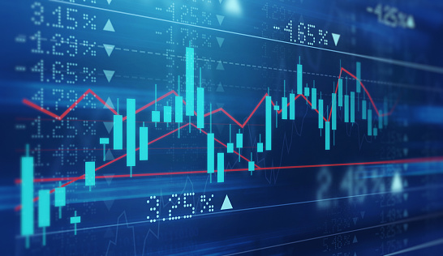

**This assignment aims to test your Python coding skills to conduct data exploration, analysis and visualisation skills.**

**2000 Word count excludes Tables, Figures, caption for Tables and Figures.**

,

In this assignment, you are given stock market data from a major Stock Market Index. This assignment aims to scrutinise stock market data by

- Descriptive statistics of the dataset
- Data visualisation
- Recommendations and observations based on data analysis & visualisation

#### **Data description:**

The stock market data is in the `.csv` file, the name of this file is the `financials.csv`. Please download both files from the canvas. Most variables/features name's in the stock market data file are self-explanatory.

**Columns in data:**

- `Company_Name`: Name of the company
- `Stock_Market_Sector`: A stock market sector is a group of stocks with a lot in common, usually, because they are in similar industries and sometimes identical business models.
- `Price`: Price is the most recent stock selling price.
- `Price/Earnings`: Price-to-Earnings (P/E) Ratio shows what the market is willing to pay for a stock based on its past or future earnings. A high P/E could mean that a stock's price is higher than earnings and possibly overvalued. Conversely, a low P/E might indicate that the current stock price is low relative to earnings.
- `Dividend Yield`: Dividend yield is a stock's annual dividend payments to shareholders expressed as a percentage of the stock's current price. It is the percentage of a company's share price that it pays out in dividends each year.
- `Earnings/Share`: Earnings per share (EPS) is a company's net profit divided by the number of common shares it has outstanding. It is how much money a company makes for each share of its stock and is a widely used metric for estimating corporate value.
- `52 Week Low`: The data point includes the lowest price at which a stock has traded during the previous 52 weeks. Many investors prefer to buy undervalued stocks, as it is believed that there is a high chance of such stocks to go higher in the future.
- `52 Week High`: The data point includes the highest price at which a stock has traded during the previous 52 weeks.
- `Market_Cap`: Market cap—or market capitalisation—refers to the total value of all a company's shares of stock.
- `EBITDA`: EBITDA, or earnings before interest, taxes, depreciation, and amortisation, is a measure of a company's overall financial performance and is used as an alternative to the net income in some circumstances. EBITDA, however, can be misleading because it strips out the cost of capital investments like property, plant, and equipment. https://www.investopedia.com/terms/e/ebitda.asp
- `Price/Sales`: The price-to-sales (P/S) ratio shows how much investors are willing to pay per dollar of sales for a stock. A low ratio could imply the stock is undervalued, while a higher-than-average ratio could indicate that the stock is overvalued. https://www.investopedia.com/terms/p/price-to-salesratio.asp
- `Price/Book`: The P/B ratio measures the market's valuation of a company relative to its book value. A company's book value is the difference between its total assets and total liabilities and not its share price in the market. https://www.investopedia.com/terms/p/price-to-bookratio.asp

### `Task 1`

- Import dataset `financials.csv` in Python by pandas DataFrame.
- Display the first 8 rows of both DataFrame
- Shape of a dataset is total rows and columns. What is the shape of the datasets?

### `Task 2`

- Process missing values. Identify any special characters or text used to represent missing data, such as #,?, missing, unknown etc. Explain the strategies used to handle missing values in the dataset.
- Basic statistical details like percentile, mean, std etc., of a data frame of numeric columns.
- Basic statistical details like count, unique values etc., of a data frame of categorical columns.

References for missing data imputation:  
https://www.section.io/engineering-education/complete-guide-to-dealing-with-missing-values-in-python/  
https://scikit-learn.org/stable/modules/impute.html

### `Task 3`

Conduct descriptive data analysis of the dataset:

- Plot the ranks of the percentage of stocks in each sector (Example: Heatmap, Barplot, and Piechart)
- Correlation between all features (or columns).
- Find the name of the company which has (a) Maximum & Minimum Dividend Yield (b) Maximum & Minimum Earnings/Share (c) Maximum & Minimum Price/Sales
- Calculate the probability of dividend yield greater than 2.181 for "Real Estate", "Financials", and "Energy" sectors. (hint: Binomial distribution)
- Bar plot (a) Earnings/Share for each market sector (b) Dividend Yield for each market sector (c) plot average Market Cap for each sector

Describe your observations on each plot and data analysis conducted in this task.

### `Task 4`

How can blockchain technology cut carbon emissions by moving away from a “proof of work” and other computational processes?

Write 500 words

- Could be data analysis (data from multiple sources), add additional data or material in the appendix
- Could be a literature review from scholarly sources
- Use credible references/sources such as Journals and magazines such as Times, Forbes, Harvard Business Review, MIT Sloan Management Review.